# Betting Data analysis

Manoj Suresh

### **1. Introduction**

##### **1.1 Background**

**Being a huge sports fan, I find myself spending my weekends switching the channels back and forth to catch any live action. While thinking about some exciting projects to work on to build my portfolio, I thought of integrating sport into at least 1 of them. I felt betting data had a lot of potential to give me different insights to sports betting. I searched for some existing data but was not convinced about them as I was worried about their integrity. Therefore, I decided to collect my own data. I kept track of bets that I would have made if I were to be involved in sports betting. I did not want to actually bet as I have never done it before and didn’t want to risk any of my money, therefore each weekend I would go online and research each bet I am interested in and then go on a betting website to obtain the odds. Once the event ended, I would come back to my excel to update the outcome.**

##### **1.2 About the data**

1. **Data collected is hypothetical bets I would have made over the course of 6 months from 2021 March to 2021 September.**
2. **Tipsters are people whose bets I have followed because I found value in them. These tipsters are from Reddit and Twitter.**
3. **Confidence is a subjective variable which indicated my confidence in the bet cashing. I figured it would give me an avenue to analyse my psychology of betting.**

### **2. Pre-processing data**

#### **2.1 Reading in data**

```r
bet_data <- read_excel("DA-Bets.xlsx")
head(bet_data) %>%
  kable(caption = "Betting data:") %>%
  kable_minimal(full_width = F)
```

Betting data:

| Sport / League | Selection | Bet Type | Tipper | Confidence | Fixture / Event | Stake | Odds | Win |
| --- | --- | --- | --- | --- | --- | --- | --- | --- |
| NA | NA | NA | NA | NA | NA | NA | NA | NA |
| Darts | Wright | Winner | Random | 3 | Wright vs Smith | 1.03 | 1.48 | Y |
| Baseball | Tigers | Winner | Random | 2 | Tigers vs Royals | 0.76 | 1.98 | N |
| AFL | Under 172.5/North+32.5 | Multi Bet - 2 legs | ImSmithz | 2 | Carlton vs North | 0.80 | 1.88 | N |
| AFL | Under 179.5/St +32.5 | Multi Bet - 2 legs | My own bets | 1 | Eagles vs Saints | 0.92 | 1.62 | N |
| AFL | Under 175.5/Crows +27.5 | Multi Bet - 2 legs | My own bets | 3 | Crows vs Hawks | 0.87 | 1.74 | N |

#### **2.2 Data Cleaning**

**The first row contains NA values and this needs to be removed. This is a result of my formatting in the origin excel file.**

```r
bet_data <- bet_data[-1,]
head(bet_data) %>%
  kable(caption = "Cleaned data:") %>%
  kable_minimal(full_width = F)
```

Cleaned data:

| Sport / League | Selection | Bet Type | Tipper | Confidence | Fixture / Event | Stake | Odds | Win |
| --- | --- | --- | --- | --- | --- | --- | --- | --- |
| Darts | Wright | Winner | Random | 3 | Wright vs Smith | 1.03 | 1.48 | Y |
| Baseball | Tigers | Winner | Random | 2 | Tigers vs Royals | 0.76 | 1.98 | N |
| AFL | Under 172.5/North+32.5 | Multi Bet - 2 legs | ImSmithz | 2 | Carlton vs North | 0.80 | 1.88 | N |
| AFL | Under 179.5/St +32.5 | Multi Bet - 2 legs | My own bets | 1 | Eagles vs Saints | 0.92 | 1.62 | N |
| AFL | Under 175.5/Crows +27.5 | Multi Bet - 2 legs | My own bets | 3 | Crows vs Hawks | 0.87 | 1.74 | N |
| AFL | Melbourne 1-39 | Winning Margin | My own bets | 3 | Melbourne vs Bulldogs | 0.69 | 2.20 | N |

**The ‘win’ column states whether a bet won, lost, was returned or only half of it was won. These need to be replaced with more descriptive words in order to be more intuitive to the reader.**

```r
for (i in 1:nrow(bet_data)) {

  if (bet_data[i,9] == 'Y'){
    bet_data[i,9] = "Win"
  }

  if (bet_data[i,9] == 'N'){
    bet_data[i,9] = "Lose"
  }

  if (bet_data[i,9] == 'HW'){
    bet_data[i,9] = "Half-Win"
  }

  if (bet_data[i,9] == 'R'){
    bet_data[i,9] = "Return"
  }
}

head(bet_data) %>%
  kable(caption = "Cleaned Data") %>%
  kable_minimal(full_width = F)
```

Cleaned Data

| Sport / League | Selection | Bet Type | Tipper | Confidence | Fixture / Event | Stake | Odds | Win |
| --- | --- | --- | --- | --- | --- | --- | --- | --- |
| Darts | Wright | Winner | Random | 3 | Wright vs Smith | 1.03 | 1.48 | Win |
| Baseball | Tigers | Winner | Random | 2 | Tigers vs Royals | 0.76 | 1.98 | Lose |
| AFL | Under 172.5/North+32.5 | Multi Bet - 2 legs | ImSmithz | 2 | Carlton vs North | 0.80 | 1.88 | Lose |
| AFL | Under 179.5/St +32.5 | Multi Bet - 2 legs | My own bets | 1 | Eagles vs Saints | 0.92 | 1.62 | Lose |
| AFL | Under 175.5/Crows +27.5 | Multi Bet - 2 legs | My own bets | 3 | Crows vs Hawks | 0.87 | 1.74 | Lose |
| AFL | Melbourne 1-39 | Winning Margin | My own bets | 3 | Melbourne vs Bulldogs | 0.69 | 2.20 | Lose |

*Data is pretty clean as I recorded them in a suitable way for me to do analysis. There may be some cleaning done further down the line as and when necessary.*

### **3. Exploratory Data Analysis**

#### **3.1 Proportion of each outcome**

*Firstly, I thought it’d be good to look at my win ratios among all the bets placed:*

```r
result_summary <-
  bet_data %>%
  count(bet_data$Win) %>%
  rename(Outcome = 1) %>%
  rename(Count = 2)

#Obtaining percentages:
result_summary <- result_summary %>%
  mutate(Percentage = label_percent()(result_summary$Count /
                                        sum(result_summary$Count)))
#Ordering:

result_summary <- result_summary[order(-result_summary$Count),]

result_summary %>%
  kable(caption = "Summary:") %>%
  kable_minimal(full_width = F)
```

Summary:

| Outcome | Count | Percentage |
| --- | --- | --- |
| Win | 45 | 52.3% |
| Lose | 35 | 40.7% |
| Return | 4 | 4.7% |
| Half-Win | 2 | 2.3% |

**It seems like I have done well as the majority of my bets have ended up cashing. There are a small number of bets returned due to them being voided. This may have been due to several reasons such as the cancellation of the event or that particular player not being involved in the match. A couple of bets are categorised as ‘Half-Win’ as I felt the cash out opportunity was favourable, regardless of it being to cut-losses or to secure profits early.**

**Below is a visualisation of the above information for more intuitive readers.**

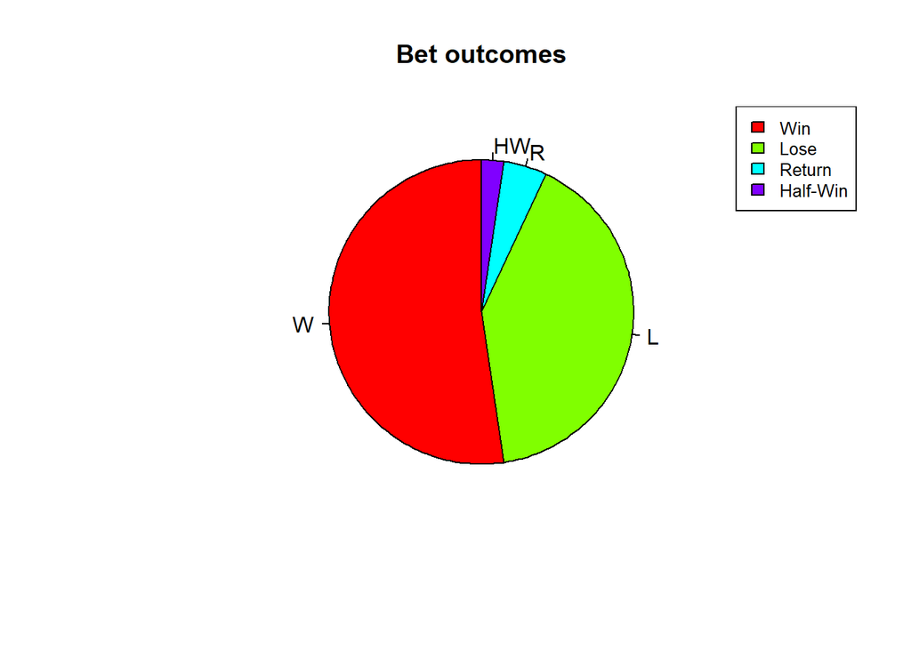

```r
pie(result_summary$Count,
    main = "Bet outcomes",
    init.angle = 90,
    col = rainbow(4),
    labels = c("W","L","R","HW"))
legend("topright", result_summary$Outcome, cex = 0.8, fill = rainbow(4))
```

#### **3.2 Performance by sport**

**To accurately visualise the performance by sport, we need a data set which contains the number of times each outcome occured per sport. This is shown below:**

```r
bysportabsolute <- bet_data %>%
  mutate(Count = 1) %>%
  group_by(`Sport / League`,
           Win) %>%
  summarise(Count = sum(Count)) %>%
  rename(Sport = 1)

bysport <- bysportabsolute %>%
  add_column((bysportabsolute %>%
                         group_by(Sport) %>%
                         summarise(per = Count/sum(Count)))[,2]) %>%
  rename(`Proportion within sport` = per)

bysport %>%
  kable(caption = "Outcomes by sport:") %>%
  kable_minimal(full_width = F)
```

Outcomes by sport:

| Sport | Win | Count | Proportion within sport |
| --- | --- | --- | --- |
| AFL | Lose | 9 | 0.6428571 |
| AFL | Win | 5 | 0.3571429 |
| Baseball | Lose | 4 | 0.4000000 |
| Baseball | Return | 1 | 0.1000000 |
| Baseball | Win | 5 | 0.5000000 |
| Basketball | Win | 1 | 1.0000000 |
| Darts | Half-Win | 1 | 0.3333333 |
| Darts | Win | 2 | 0.6666667 |
| Horse Racing | Lose | 1 | 0.3333333 |
| Horse Racing | Win | 2 | 0.6666667 |
| MLB | Win | 1 | 1.0000000 |
| Soccer | Half-Win | 1 | 0.0217391 |
| Soccer | Lose | 19 | 0.4130435 |
| Soccer | Return | 3 | 0.0652174 |
| Soccer | Win | 23 | 0.5000000 |
| Tennis | Lose | 2 | 0.2500000 |
| Tennis | Win | 6 | 0.7500000 |

**As it can be seen, there’s a bit of difference in the number of bets placed per sport. Having played and watched soccer for pretty much my whole life, I naturally feel more confident in placing soccer bets as I believe I have the expertise to do so. Therefore, I have chosen a grouped bar chart to visualise the above information as it also contains information about the number of bets placed per sport compared to a 100% stacked bar chart. A 100% stacked bar chart can be useful when viewed in conjuction witht the grouped bar chart but not on its own as it does not convey information regarding the number of bets placed.**

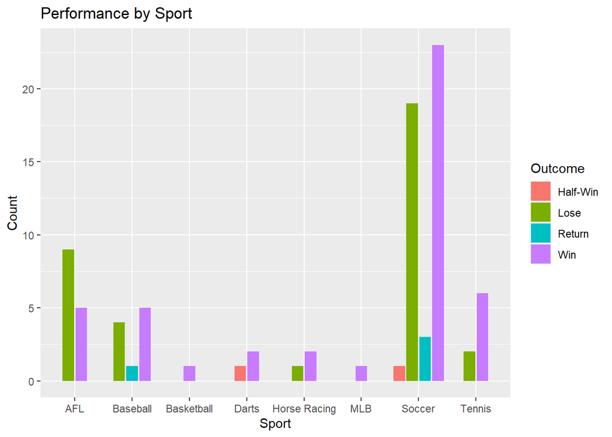

```r
ggplot(bysport,
       aes(fill = Win,
           x = Sport,
           y = Count)) +
  geom_col(position = position_dodge2(preserve = "single")) +
  scale_fill_discrete(name = "Outcome") +
  labs(title = "Performance by Sport")
```

**For example, the below stacked bar chart leads readers to believe that I am very good at predicting the outcomes of Basketball and MLB games as it shows I have won 100% of my bets. In reality, that is the case only because I placed a single bet in each of these sports, therefore it doesn’t show a fair reflection of the data. Nevertheless, when it is consumed by the reader along with the grouped bar chart above, it can still add some context.**

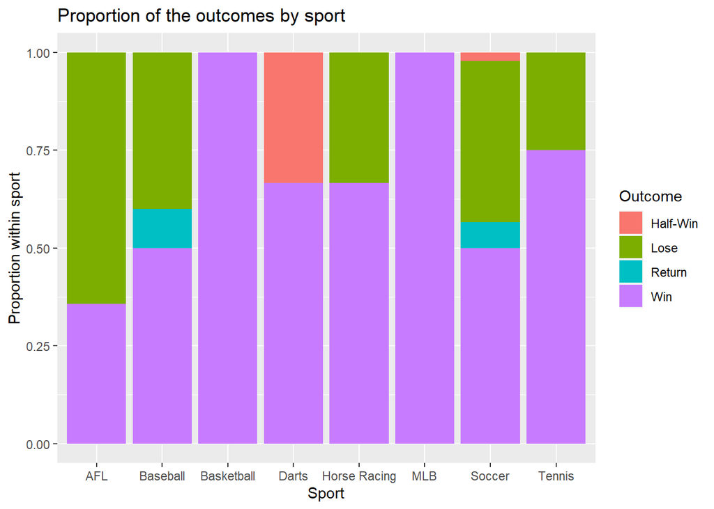

```r
ggplot(bysport,
       aes(fill = Win,
           x = Sport,
           y = `Proportion within sport`)) +
  geom_bar(position = "stack",
           stat = 'identity') +
  scale_fill_discrete(name = "Outcome") +
  labs(title = "Proportion of the outcomes by sport")
```

**Given the sample size, I seem to be pretty good at betting on soccer games while being generally poor with the AFL. I may collect more data to see if I can continue to do well in the long term.**

#### **3.3 Confidence vs Odds**

**Although I try my best to fill in the confidence column before I go and look at the odds offered (to be as unbiased as I can be), I always end up getting swayed by the odds. It’d be interesting to see if there is any relationship between my confidence level and the odds.**

**To look at the relationship, I decided to use average odds at each confidence level.**

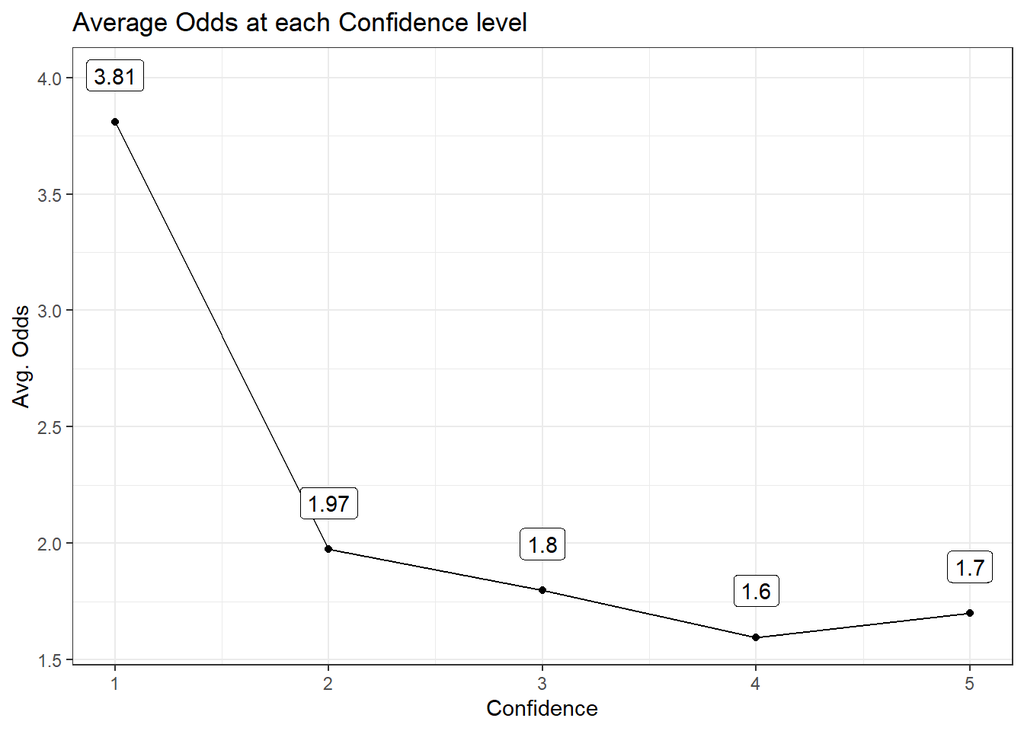

```r
avgodds <- bet_data %>%
  group_by(Confidence) %>%
  summarise(`Avg. Odds` = mean(Odds))

ggplot(avgodds,
       aes(x=Confidence,
           y=`Avg. Odds`)) +
  geom_point() +
  geom_line() +
  labs(title = "Average Odds at each Confidence level") +
  theme_bw() +
  geom_label(aes(x=Confidence,
                y = `Avg. Odds`+0.2),
            label = round(avgodds$`Avg. Odds`,2))
```

**Nothing looks unusual here, it makes sense that there is a negative relationship between confidence level and odds offered. There is a bit of a spike at confidence level 5, but that’s due to a small sample size of bets placed at that level of confidence. Same goes for confidence level of 1, the huge difference is also partly due to the small sample size. Even if the highest and lowest confidence level are ignored , the 3 in the middle show a consistent negative trend.**

#### **3.4 Stake size vs Odds**

**Having explored the trend between confidence and odds, I thought it’d be interesting to see if there is any trend between my stake sizes and odds. Stake sizes were completely based off of instinct at the time of betting, although I am sure the confidence level impacted it to a certain extent. The line graph below displays the relationship between these 2 continuous variables.**

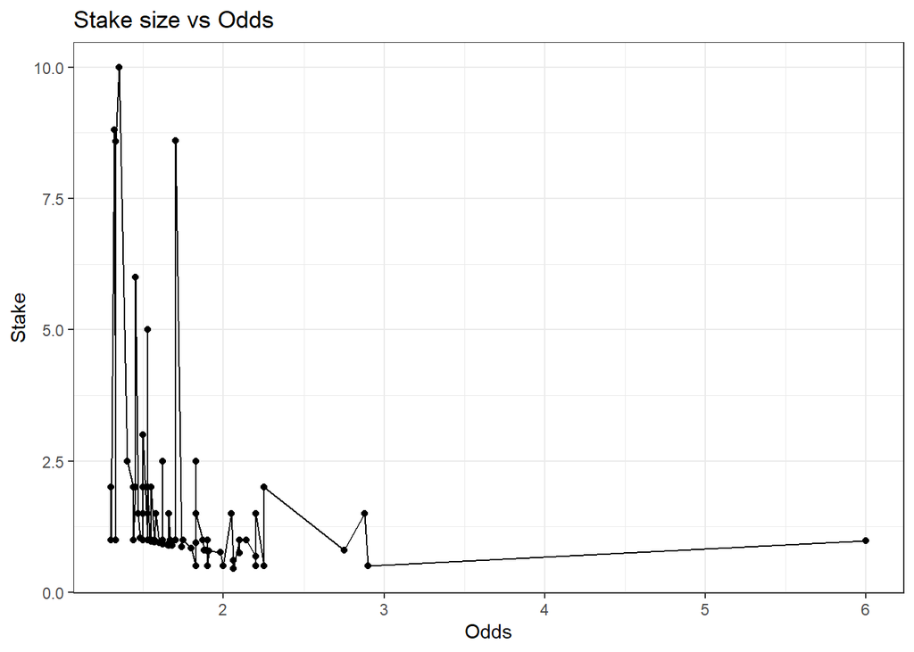

```r
ggplot(bet_data,
       aes(x=Odds,
           y=Stake)) +
  geom_point() +
  geom_line() +
  labs(title = "Stake size vs Odds") +
  theme_bw()
```

**Although there doesn’t seem to be clear trend, it can be seen that the volatility of stake size steadily decreases as the odds increase and converges closer to the x axis (indicates down trend). This again, makes sense as higher odds bets often don’t cash, and thus it is more of a gamble, and therefore, lesser money is instinctively risked.**

**While we are comparing quantitative attributes, it is worthwhile to compare stake size against confidence level to see if we can get any more insights.**

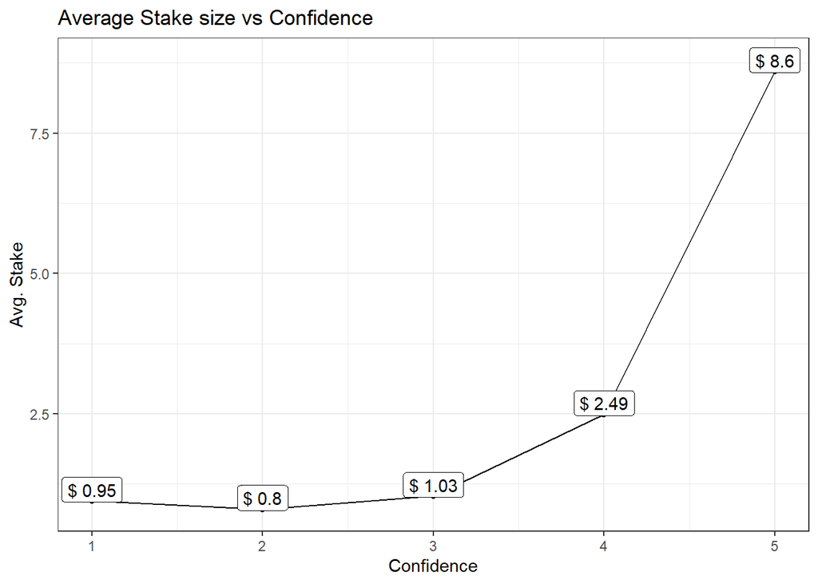

```r
confVSstake <- bet_data %>%
  group_by(Confidence) %>%
  summarise(`Avg. Stake` = mean(Stake))

ggplot(confVSstake,
       aes(x=Confidence,
           y=`Avg. Stake`)) +
  geom_point() +
  geom_line() +
  labs(title = "Average Stake size vs Confidence") +
  theme_bw() +
  geom_label(aes(x =Confidence,
                 y = `Avg. Stake`+0.2),
            label = paste("$",round(confVSstake$`Avg. Stake`,2)))
```

**A general positive trend is seen, which is relatively unsurprising. It is worthwhile to note that there is a slight drop in average stake size from confidence level 1 to confidence level 2 which goes against the general trend. This maybe due to the relatively small sample size at the lower confidence levels.**

### **4. Conclusion**

**I am still collecting data on this subject and hope to continue my analysis with a much larger sameple size which can provide us with more accurate data for the long-term.**